# Part II - Communicate findings from Prosper Loan Data

## by Doriane Ishimwe Ntaganda

## Investigation Overview

> Using exploratory and explanatory data analysis, the goal of this project is to communicate findings from loan data at prosper.

## Dataset Overview

> This project will explore the factors considered when giving loans at Prosper Marketplace Inc. a company that provides loans to borrowers. The dataset contains 113,937 loans with 81 variables on each loan, including loan amount, borrower rate (or interest rate), current loan status, borrower income, and many others. Based on the mentioned variables a loan can be granted or denied.

## Relationship between Loan Status and Terms

> This Chat decipts the loan status in accordance to terms.Those in current category outweighs others and Also in all status of loan, few people take a loan of one year while a high number prefer 3 years which is term 36

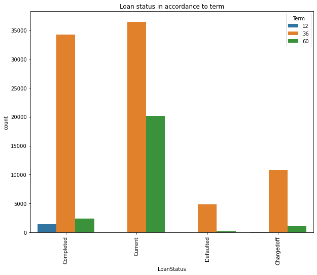

## Relationship among Loan Status, Home owner and Prosper Rating

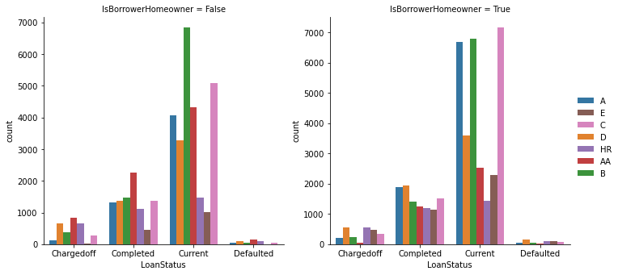

## Number of obeservation according to Employment status

> 67322 people who got a loan are from Employed category which contains more people compared to the rest of categories

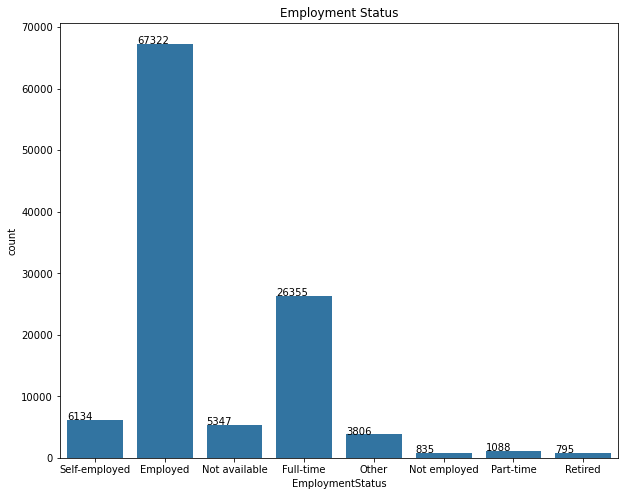